# Joining Data with dplyr

Paris Zhang

4/16/2020

Taught by *Chris Cardillo*, Data Scientist at DataCamp. [Course link](https://learn.datacamp.com/courses/joining-data-with-dplyr-b3f91a4a-4a9d-4a6f-b655-292a1641c3e2)

This is a comprehensive notes on `inner_join()`, `left_join()`, `right_join()`, `full_join()`, `semi_join()`, and `anti_join()`.

```r
# Data manipulation
library(dplyr)

# To use replace_na()
library(tidyr)

# Data visualization
library(ggplot2)
library(forcats)

# Beautiful table presentation
library(knitr) # May not use kable() in this note

# Overview data summary
library(summarytools) # May not use dfSummary() in this note

# Applies classic ggplot2 theme
theme_set(theme_classic())
```

# 1. Inner Join

- `parts` is a list of all LEGO parts
- `part_categories` with these parts’ corresponding categories
- `inventory_parts` has some additional information about those parts, such as the `color_id` of each part you would find in a specific LEGO kit

## 1.1 The `inner_join` verb

The Sets data

```r
sets = readRDS("data/sets.rds")
themes = readRDS("data/themes.rds")

head(sets)
```

```
## # A tibble: 6 x 4
##   set_num   name                                                   year theme_id
##   <chr>     <chr>                                                 <dbl>    <dbl>
## 1 700.3-1   Medium Gift Set (ABB)                                  1949      365
## 2 700.1.1-1 Single 2 x 4 Brick (ABB)                               1950      371
## 3 700.B.2-1 Single 1 x 2 x 3 Window without Glass (ABB)            1950      371
## 4 700.1-2   Extra-Large Gift Set (Mursten)                         1953      366
## 5 700.F-1   Automatic Binding Bricks - Small Brick Set (Lego Mur…  1953      371
## 6 700.24-1  Individual 2 x 12 Bricks                               1954      371
```

```r
head(themes)
```

```
## # A tibble: 6 x 3
##      id name           parent_id
##   <dbl> <chr>              <dbl>
## 1     1 Technic               NA
## 2     2 Arctic Technic         1
## 3     3 Competition            1
## 4     4 Expert Builder         1
## 5     5 Model                  1
## 6     6 Airport                5
```

Inner join:

```r
sets %>%
  inner_join(themes, by = c("theme_id" = "id"))
```

```
## # A tibble: 4,977 x 6
##    set_num   name.x                            year theme_id name.y    parent_id
##    <chr>     <chr>                            <dbl>    <dbl> <chr>         <dbl>
##  1 700.3-1   Medium Gift Set (ABB)             1949      365 System           NA
##  2 700.1.1-1 Single 2 x 4 Brick (ABB)          1950      371 Suppleme…       365
##  3 700.B.2-1 Single 1 x 2 x 3 Window without…  1950      371 Suppleme…       365
##  4 700.1-2   Extra-Large Gift Set (Mursten)    1953      366 Basic Set       365
##  5 700.F-1   Automatic Binding Bricks - Smal…  1953      371 Suppleme…       365
##  6 700.24-1  Individual 2 x 12 Bricks          1954      371 Suppleme…       365
##  7 700.C.1-1 Individual 1 x 6 x 4 Panorama W…  1954      371 Suppleme…       365
##  8 700.C.4-1 Individual 1 x 4 x 3 Window (wi…  1954      371 Suppleme…       365
##  9 700.H-1   Individual 4 x 4 Corner Bricks    1954      371 Suppleme…       365
## 10 1200-1    LEGO Town Plan Board, Large Pla…  1955      372 Town Plan       365
## # … with 4,967 more rows
```

Inner join with customization:

```r
# Column names will add a suffix when duplicates are produced
## name.x -> name_set
## name.y -> name_theme
sets %>%
  inner_join(themes, by = c("theme_id" = "id"), suffix = c("_set", "_theme"))
```

```
## # A tibble: 4,977 x 6
##    set_num  name_set                          year theme_id name_theme parent_id
##    <chr>    <chr>                            <dbl>    <dbl> <chr>          <dbl>
##  1 700.3-1  Medium Gift Set (ABB)             1949      365 System            NA
##  2 700.1.1… Single 2 x 4 Brick (ABB)          1950      371 Supplemen…       365
##  3 700.B.2… Single 1 x 2 x 3 Window without…  1950      371 Supplemen…       365
##  4 700.1-2  Extra-Large Gift Set (Mursten)    1953      366 Basic Set        365
##  5 700.F-1  Automatic Binding Bricks - Smal…  1953      371 Supplemen…       365
##  6 700.24-1 Individual 2 x 12 Bricks          1954      371 Supplemen…       365
##  7 700.C.1… Individual 1 x 6 x 4 Panorama W…  1954      371 Supplemen…       365
##  8 700.C.4… Individual 1 x 4 x 3 Window (wi…  1954      371 Supplemen…       365
##  9 700.H-1  Individual 4 x 4 Corner Bricks    1954      371 Supplemen…       365
## 10 1200-1   LEGO Town Plan Board, Large Pla…  1955      372 Town Plan        365
## # … with 4,967 more rows
```

Most common themes:

```r
sets %>%
  inner_join(themes, by = c("theme_id" = "id"), suffix = c("_set", "_theme")) %>%
  count(name_theme, sort = TRUE)
```

```
## # A tibble: 419 x 2
##    name_theme        n
##    <chr>         <int>
##  1 Supplemental    180
##  2 Basic Set       171
##  3 Technic         144
##  4 Friends         133
##  5 Gear            122
##  6 City            120
##  7 Town            117
##  8 Ninjago          95
##  9 Service Packs    94
## 10 Star Wars        94
## # … with 409 more rows
```

## 1.2 Joining with a one-to-many relationship

Joinging `sets` and `themes` returned a 4,977 $\times$ 6 table.

The `inventories` table:

```r
inventories = readRDS("data/inventories.rds")
head(inventories)
```

```
## # A tibble: 6 x 3
##      id version set_num
##   <dbl>   <dbl> <chr>
## 1     1       1 7922-1
## 2     3       1 3931-1
## 3     4       1 6942-1
## 4    15       1 5158-1
## 5    16       1 903-1
## 6    17       1 850950-1
```

Joining sets and inventories returns a 5,056 x 6 table.

```r
sets %>%
  inner_join(inventories, by = "set_num")
```

```
## # A tibble: 5,056 x 6
##    set_num   name                                    year theme_id    id version
##    <chr>     <chr>                                  <dbl>    <dbl> <dbl>   <dbl>
##  1 700.3-1   Medium Gift Set (ABB)                   1949      365 24197       1
##  2 700.3-1   Medium Gift Set (ABB)                   1949      365 24214       2
##  3 700.3-1   Medium Gift Set (ABB)                   1949      365 24215       3
##  4 700.1.1-1 Single 2 x 4 Brick (ABB)                1950      371 11831       1
##  5 700.1.1-1 Single 2 x 4 Brick (ABB)                1950      371 24230       2
##  6 700.1.1-1 Single 2 x 4 Brick (ABB)                1950      371 24231       3
##  7 700.1.1-1 Single 2 x 4 Brick (ABB)                1950      371 24232       4
##  8 700.1.1-1 Single 2 x 4 Brick (ABB)                1950      371 24233       5
##  9 700.B.2-1 Single 1 x 2 x 3 Window without Glass…  1950      371   537       1
## 10 700.B.2-1 Single 1 x 2 x 3 Window without Glass…  1950      371 24240       2
## # … with 5,046 more rows
```

Filtering the joined table returns a 4,976 x 6 table; 1 set has no version 1 - this could be a quality issue

```r
sets %>%
  inner_join(inventories, by = "set_num") %>%
  filter(version == 1)
```

```
## # A tibble: 4,976 x 6
##    set_num   name                                    year theme_id    id version
##    <chr>     <chr>                                  <dbl>    <dbl> <dbl>   <dbl>
##  1 700.3-1   Medium Gift Set (ABB)                   1949      365 24197       1
##  2 700.1.1-1 Single 2 x 4 Brick (ABB)                1950      371 11831       1
##  3 700.B.2-1 Single 1 x 2 x 3 Window without Glass…  1950      371   537       1
##  4 700.1-2   Extra-Large Gift Set (Mursten)          1953      366 12985       1
##  5 700.F-1   Automatic Binding Bricks - Small Bric…  1953      371 11265       1
##  6 700.24-1  Individual 2 x 12 Bricks                1954      371  7645       1
##  7 700.C.1-1 Individual 1 x 6 x 4 Panorama Window …  1954      371  3896       1
##  8 700.C.4-1 Individual 1 x 4 x 3 Window (with gla…  1954      371  3663       1
##  9 700.H-1   Individual 4 x 4 Corner Bricks          1954      371 15503       1
## 10 1200-1    LEGO Town Plan Board, Large Plastic     1955      372 10761       1
## # … with 4,966 more rows
```

## 1.3 Joining three or more tables

Joining `sets`, `inventories`, and `themes`:

```r
sets %>%
  inner_join(inventories, by = "set_num") %>%
  inner_join(themes, by = c("theme_id" = "id"), suffix = c("_set", "_theme"))
```

```
## # A tibble: 5,056 x 8
##    set_num  name_set            year theme_id    id version name_theme parent_id
##    <chr>    <chr>              <dbl>    <dbl> <dbl>   <dbl> <chr>          <dbl>
##  1 700.3-1  Medium Gift Set (…  1949      365 24197       1 System            NA
##  2 700.3-1  Medium Gift Set (…  1949      365 24214       2 System            NA
##  3 700.3-1  Medium Gift Set (…  1949      365 24215       3 System            NA
##  4 700.1.1… Single 2 x 4 Bric…  1950      371 11831       1 Supplemen…       365
##  5 700.1.1… Single 2 x 4 Bric…  1950      371 24230       2 Supplemen…       365
##  6 700.1.1… Single 2 x 4 Bric…  1950      371 24231       3 Supplemen…       365
##  7 700.1.1… Single 2 x 4 Bric…  1950      371 24232       4 Supplemen…       365
##  8 700.1.1… Single 2 x 4 Bric…  1950      371 24233       5 Supplemen…       365
##  9 700.B.2… Single 1 x 2 x 3 …  1950      371   537       1 Supplemen…       365
## 10 700.B.2… Single 1 x 2 x 3 …  1950      371 24240       2 Supplemen…       365
## # … with 5,046 more rows
```

Review Slides - Chapter 1 - p.24 for data structures (key chains).

# 2. Left and Right Join

## 2.1 The `left_join` verb

```r
inventory_parts = readRDS("data/inventory_parts.rds")
inventory_parts_joined <- inventories %>%
  inner_join(inventory_parts, by = c("id" = "inventory_id")) %>%
  select(-id, -version) %>%
  arrange(desc(quantity))

# Filter for LEGO sets
batmobile <- inventory_parts_joined %>%
  filter(set_num == "7784-1") %>%
  select(-set_num)
batwing <- inventory_parts_joined %>%
  filter(set_num == "70916-1") %>%
  select(-set_num)

head(batmobile)
```

```
## # A tibble: 6 x 3
##   part_num color_id quantity
##   <chr>       <dbl>    <dbl>
## 1 3023           72       62
## 2 2780            0       28
## 3 50950           0       28
## 4 3004           71       26
## 5 43093           1       25
## 6 3004            0       23
```

```r
head(batwing)
```

```
## # A tibble: 6 x 3
##   part_num color_id quantity
##   <chr>       <dbl>    <dbl>
## 1 3023            0       22
## 2 3024            0       22
## 3 3623            0       20
## 4 11477           0       18
## 5 99207          71       18
## 6 2780            0       17
```

Joining with multiple columns (`batmobile` is 173 x 3, `batwing` is 309 x 3):

```r
batmobile %>%
  inner_join(batwing, by = c("part_num", "color_id"), suffix = c("_batmobile", "_batwing"))
```

```
## # A tibble: 45 x 4
##    part_num color_id quantity_batmobile quantity_batwing
##    <chr>       <dbl>              <dbl>            <dbl>
##  1 2780            0                 28               17
##  2 50950           0                 28                2
##  3 3004           71                 26                2
##  4 43093           1                 25                6
##  5 3004            0                 23                4
##  6 3622            0                 18                2
##  7 4286            0                 16                1
##  8 3039            0                 12                2
##  9 4274           71                 12                7
## 10 3001            0                 11                4
## # … with 35 more rows
```

The left join (retains 173 rows):

```r
batmobile %>%
  left_join(batwing, by = c("part_num", "color_id"), suffix = c("_batmobile", "_batwing"))
```

```
## # A tibble: 173 x 4
##    part_num color_id quantity_batmobile quantity_batwing
##    <chr>       <dbl>              <dbl>            <dbl>
##  1 3023           72                 62               NA
##  2 2780            0                 28               17
##  3 50950           0                 28                2
##  4 3004           71                 26                2
##  5 43093           1                 25                6
##  6 3004            0                 23                4
##  7 3010            0                 21               NA
##  8 30363           0                 21               NA
##  9 32123b         14                 19               NA
## 10 3622            0                 18                2
## # … with 163 more rows
```

## 2.2 The `right_join` verb

Right join is the mirror image of left join.

1. Left join (173 rows)

```r
batmobile %>%
  left_join(batwing, by = c("part_num", "color_id"), suffix = c("_batmobile", "_batwing"))
```

```
## # A tibble: 173 x 4
##    part_num color_id quantity_batmobile quantity_batwing
##    <chr>       <dbl>              <dbl>            <dbl>
##  1 3023           72                 62               NA
##  2 2780            0                 28               17
##  3 50950           0                 28                2
##  4 3004           71                 26                2
##  5 43093           1                 25                6
##  6 3004            0                 23                4
##  7 3010            0                 21               NA
##  8 30363           0                 21               NA
##  9 32123b         14                 19               NA
## 10 3622            0                 18                2
## # … with 163 more rows
```

2. Right join (312 rows)

```r
batmobile %>%
  right_join(batwing, by = c("part_num", "color_id"), suffix = c("_batmobile", "_batwing"))
```

```
## # A tibble: 312 x 4
##    part_num color_id quantity_batmobile quantity_batwing
##    <chr>       <dbl>              <dbl>            <dbl>
##  1 3023            0                 NA               22
##  2 3024            0                  2               22
##  3 3623            0                 10               20
##  4 11477           0                 NA               18
##  5 99207          71                 NA               18
##  6 2780            0                 28               17
##  7 2780            0                  1               17
##  8 3666            0                 NA               16
##  9 22385           0                 NA               14
## 10 3710            0                 NA               14
## # … with 302 more rows
```

Compare inner join and right join to serve different purposes:

```r
sets %>%
  count(theme_id, sort = TRUE) %>%
  inner_join(themes, by = c("theme_id" = "id"))
```

```
## # A tibble: 569 x 4
##    theme_id     n name              parent_id
##       <dbl> <int> <chr>                 <dbl>
##  1      501   122 Gear                     NA
##  2      494   111 Friends                  NA
##  3      435    94 Ninjago                  NA
##  4      505    94 Basic Set               504
##  5      632    93 Town                    504
##  6      371    89 Supplemental            365
##  7      497    86 Books                    NA
##  8      503    82 Key Chain               501
##  9      516    78 Duplo and Explore       507
## 10      220    72 City                    217
## # … with 559 more rows
```

```r
sets %>%
  count(theme_id, sort = TRUE) %>%
  right_join(themes, by = c("theme_id" = "id")) %>%
  replace_na(list(n = 0))
```

```
## # A tibble: 665 x 4
##    theme_id     n name           parent_id
##       <dbl> <dbl> <chr>              <dbl>
##  1        1    58 Technic               NA
##  2        2     1 Arctic Technic         1
##  3        3     4 Competition            1
##  4        4    13 Expert Builder         1
##  5        5     6 Model                  1
##  6        6     7 Airport                5
##  7        7    20 Construction           5
##  8        8     0 Farm                   5
##  9        9     2 Fire                   5
## 10       10     3 Harbor                 5
## # … with 655 more rows
```

## 2.3 Joining tables to themselves

### Example 1. Lord of the rings

`themes` hierarchy:

```r
themes
```

```
## # A tibble: 665 x 3
##       id name           parent_id
##    <dbl> <chr>              <dbl>
##  1     1 Technic               NA
##  2     2 Arctic Technic         1
##  3     3 Competition            1
##  4     4 Expert Builder         1
##  5     5 Model                  1
##  6     6 Airport                5
##  7     7 Construction           5
##  8     8 Farm                   5
##  9     9 Fire                   5
## 10    10 Harbor                 5
## # … with 655 more rows
```

Child-parent table:

```r
themes %>%
  inner_join(themes, by = c("parent_id" = "id"), suffix = c("_child", "_parent"))
```

```
## # A tibble: 544 x 5
##       id name_child     parent_id name_parent parent_id_parent
##    <dbl> <chr>              <dbl> <chr>                  <dbl>
##  1     2 Arctic Technic         1 Technic                   NA
##  2     3 Competition            1 Technic                   NA
##  3     4 Expert Builder         1 Technic                   NA
##  4     5 Model                  1 Technic                   NA
##  5     6 Airport                5 Model                      1
##  6     7 Construction           5 Model                      1
##  7     8 Farm                   5 Model                      1
##  8     9 Fire                   5 Model                      1
##  9    10 Harbor                 5 Model                      1
## 10    11 Off-Road               5 Model                      1
## # … with 534 more rows
```

Lord ofthe Rings themes: parent

```r
themes %>%
  inner_join(themes, by = c("parent_id"="id"), suffix = c("_child","_parent")) %>%
  filter(name_child == "The Lord of the Rings")
```

```
## # A tibble: 1 x 5
##      id name_child         parent_id name_parent                parent_id_parent
##   <dbl> <chr>                  <dbl> <chr>                                 <dbl>
## 1   566 The Lord of the R…       561 The Hobbit and Lord of th…               NA
```

Lord ofthe Rings themes: children

```r
themes %>%
  inner_join(themes, by = c("parent_id"="id"), suffix = c("_child","_parent")) %>%
  filter(name_parent == "The Lord of the Rings")
```

```
## # A tibble: 3 x 5
##      id name_child                parent_id name_parent         parent_id_parent
##   <dbl> <chr>                         <dbl> <chr>                          <dbl>
## 1   567 The Fellowship of the Ri…       566 The Lord of the Ri…              561
## 2   568 The Two Towers                  566 The Lord of the Ri…              561
## 3   569 The Return of the King          566 The Lord of the Ri…              561
```

Review slides Chapter 2 p.27 for the trilogy structure.

### Example 2. Harry Potter

In this exercise, you’ll try a similar approach of joining themes to their own children, which is similar but reversed. Let’s try this out to discover what children the theme `"Harry Potter"` has.

Joining themes to their children:

```r
themes %>%
    # Inner join the themes table
    inner_join(themes, by = c("id"="parent_id"), suffix = c("_parent","_child")) %>%
    # Filter for the "Harry Potter" parent name
    filter(name_parent == "Harry Potter")
```

```
## # A tibble: 6 x 5
##      id name_parent  parent_id id_child name_child
##   <dbl> <chr>            <dbl>    <dbl> <chr>
## 1   246 Harry Potter        NA      247 Chamber of Secrets
## 2   246 Harry Potter        NA      248 Goblet of Fire
## 3   246 Harry Potter        NA      249 Order of the Phoenix
## 4   246 Harry Potter        NA      250 Prisoner of Azkaban
## 5   246 Harry Potter        NA      251 Sorcerer's Stone
## 6   246 Harry Potter        NA      667 Fantastic Beasts
```

Joining themes to their grandchildren:

```r
# Join themes to itself again to find the grandchild relationships
themes %>%
  inner_join(themes, by = c("id" = "parent_id"), suffix = c("_parent", "_child")) %>%
  inner_join(themes, by = c("id_child" = "parent_id"), suffix = c("_parent","_grandchild"))
```

```
## # A tibble: 158 x 7
##    id_parent name_parent parent_id id_child name_child id_grandchild name
##        <dbl> <chr>           <dbl>    <dbl> <chr>              <dbl> <chr>
##  1         1 Technic            NA        5 Model                  6 Airport
##  2         1 Technic            NA        5 Model                  7 Constructi…
##  3         1 Technic            NA        5 Model                  8 Farm
##  4         1 Technic            NA        5 Model                  9 Fire
##  5         1 Technic            NA        5 Model                 10 Harbor
##  6         1 Technic            NA        5 Model                 11 Off-Road
##  7         1 Technic            NA        5 Model                 12 Race
##  8         1 Technic            NA        5 Model                 13 Riding Cyc…
##  9         1 Technic            NA        5 Model                 14 Robot
## 10         1 Technic            NA        5 Model                 15 Traffic
## # … with 148 more rows
```

Left-joining a table to itself:

```r
themes %>%
  # Left join the themes table to its own children
  left_join(themes, by = c("id"="parent_id"), suffix = c("_parent","_child")) %>%
  # Filter for themes that have no child themes
  filter(is.na(name_child))
```

```
## # A tibble: 586 x 5
##       id name_parent    parent_id id_child name_child
##    <dbl> <chr>              <dbl>    <dbl> <chr>
##  1     2 Arctic Technic         1       NA <NA>
##  2     3 Competition            1       NA <NA>
##  3     4 Expert Builder         1       NA <NA>
##  4     6 Airport                5       NA <NA>
##  5     7 Construction           5       NA <NA>
##  6     8 Farm                   5       NA <NA>
##  7     9 Fire                   5       NA <NA>
##  8    10 Harbor                 5       NA <NA>
##  9    11 Off-Road               5       NA <NA>
## 10    12 Race                   5       NA <NA>
## # … with 576 more rows
```

# 3. Full, Semi, and Anti Joins

## 3.1 The `full_join` verb

```r
batmobile %>%
  full_join(batwing, by = c("part_num", "color_id"), suffix = c("_batmobile", "_batwing"))
```

```
## # A tibble: 440 x 4
##    part_num color_id quantity_batmobile quantity_batwing
##    <chr>       <dbl>              <dbl>            <dbl>
##  1 3023           72                 62               NA
##  2 2780            0                 28               17
##  3 50950           0                 28                2
##  4 3004           71                 26                2
##  5 43093           1                 25                6
##  6 3004            0                 23                4
##  7 3010            0                 21               NA
##  8 30363           0                 21               NA
##  9 32123b         14                 19               NA
## 10 3622            0                 18                2
## # … with 430 more rows
```

Replace NA: multiple variables

```r
batmobile %>%
  full_join(batwing, by = c("part_num", "color_id"), suffix = c("_batmobile", "_batwing")) %>%
  replace_na(list(quantity_batmobile = 0,
                  quantity_batwing = 0))
```

```
## # A tibble: 440 x 4
##    part_num color_id quantity_batmobile quantity_batwing
##    <chr>       <dbl>              <dbl>            <dbl>
##  1 3023           72                 62                0
##  2 2780            0                 28               17
##  3 50950           0                 28                2
##  4 3004           71                 26                2
##  5 43093           1                 25                6
##  6 3004            0                 23                4
##  7 3010            0                 21                0
##  8 30363           0                 21                0
##  9 32123b         14                 19                0
## 10 3622            0                 18                2
## # … with 430 more rows
```

## 3.2 The `semi_join` and `anti_join` verbs

These two joins are filtering joins. They Keep or remove observations from the first table:

1. `semi_join()` - What observations in X are also in Y?
2. `anti_join()` - What observations in X are not in Y?

45 observations in `batmobile` are also in `batwing` based on `color_id` and `part_num`:

```r
batmobile %>%
  semi_join(batwing, by = c("color_id", "part_num"))
```

```
## # A tibble: 45 x 3
##    part_num color_id quantity
##    <chr>       <dbl>    <dbl>
##  1 2780            0       28
##  2 50950           0       28
##  3 3004           71       26
##  4 43093           1       25
##  5 3004            0       23
##  6 3622            0       18
##  7 4286            0       16
##  8 3039            0       12
##  9 4274           71       12
## 10 3001            0       11
## # … with 35 more rows
```

128 observations in `batmobile` are not in `batwing` based on `color_id` and `part_num`:

```r
batmobile %>%
  anti_join(batwing, by = c("color_id", "part_num"))
```

```
## # A tibble: 128 x 3
##    part_num color_id quantity
##    <chr>       <dbl>    <dbl>
##  1 3023           72       62
##  2 3010            0       21
##  3 30363           0       21
##  4 32123b         14       19
##  5 50950         320       18
##  6 6541            0       18
##  7 3040b           0       14
##  8 3298            0       14
##  9 3660            0       14
## 10 42022           0       14
## # … with 118 more rows
```

Filtering with semi join:

```r
themes %>%
  semi_join(sets, by = c("id" = "theme_id"))
```

```
## # A tibble: 569 x 3
##       id name           parent_id
##    <dbl> <chr>              <dbl>
##  1     1 Technic               NA
##  2     2 Arctic Technic         1
##  3     3 Competition            1
##  4     4 Expert Builder         1
##  5     5 Model                  1
##  6     6 Airport                5
##  7     7 Construction           5
##  8     9 Fire                   5
##  9    10 Harbor                 5
## 10    11 Off-Road               5
## # … with 559 more rows
```

Filtering with anti join:

```r
themes %>%
  anti_join(sets, by = c("id" = "theme_id"))
```

```
## # A tibble: 96 x 3
##       id name         parent_id
##    <dbl> <chr>            <dbl>
##  1     8 Farm                 5
##  2    24 Airport             23
##  3    25 Castle              23
##  4    26 Construction        23
##  5    27 Race                23
##  6    28 Harbor              23
##  7    29 Train               23
##  8    32 Robot               23
##  9    34 Building            23
## 10    35 Cargo               23
## # … with 86 more rows
```

## 3.3 Visualizing set differences

Step 1. Aggregating sets into colors

```r
batmobile_colors <- batmobile %>%
  group_by(color_id) %>%
  summarize(total = sum(quantity))
batmobile_colors
```

```
## # A tibble: 12 x 2
##    color_id total
##       <dbl> <dbl>
##  1        0   543
##  2        1    33
##  3        4    16
##  4       14    20
##  5       15    16
##  6       36    15
##  7       57     8
##  8       71   202
##  9       72   160
## 10      182     8
## 11      297     4
## 12      320    27
```

```r
batwing_colors <- batwing %>%
  group_by(color_id) %>%
  summarize(total = sum(quantity))
batwing_colors
```

```
## # A tibble: 20 x 2
##    color_id total
##       <dbl> <dbl>
##  1        0   418
##  2        1    45
##  3        4    81
##  4       14    22
##  5       15    22
##  6       19    10
##  7       25     1
##  8       34     3
##  9       36     9
## 10       46    21
## 11       47     4
## 12       52     4
## 13       57     3
## 14       70    16
## 15       71   158
## 16       72   213
## 17       78     3
## 18       80     4
## 19      179     1
## 20      182    14
```

Step 2. Comparing color schemes of sets

```r
colors <- readRDS("data/colors.rds")

colors_joined <- batmobile_colors %>%
  full_join(batwing_colors, by = "color_id", suffix = c("_batmobile", "_batwing")) %>%
  replace_na(list(total_batmobile = 0, total_batwing = 0)) %>%
  # Adding the color names
  inner_join(colors, by = c("color_id" = "id")) %>%
  # Adding percentages
  mutate(total_batmobile = total_batmobile / sum(total_batmobile), # Normalization
         total_batwing = total_batwing / sum(total_batwing),
         # The difference between fractions
         difference = total_batmobile - total_batwing)
colors_joined
```

```
## # A tibble: 22 x 6
##    color_id total_batmobile total_batwing name              rgb     difference
##       <dbl>           <dbl>         <dbl> <chr>             <chr>        <dbl>
##  1        0         0.516         0.397   Black             #05131D    0.119
##  2        1         0.0314        0.0428  Blue              #0055BF   -0.0114
##  3        4         0.0152        0.0770  Red               #C91A09   -0.0618
##  4       14         0.0190        0.0209  Yellow            #F2CD37   -0.00190
##  5       15         0.0152        0.0209  White             #FFFFFF   -0.00570
##  6       36         0.0143        0.00856 Trans-Red         #C91A09    0.00570
##  7       57         0.00760       0.00285 Trans-Neon Orange #FF800D    0.00475
##  8       71         0.192         0.150   Light Bluish Gray #A0A5A9    0.0418
##  9       72         0.152         0.202   Dark Bluish Gray  #6C6E68   -0.0504
## 10      182         0.00760       0.0133  Trans-Orange      #F08F1C   -0.00570
## # … with 12 more rows
```

Step 3. Visualizing the data

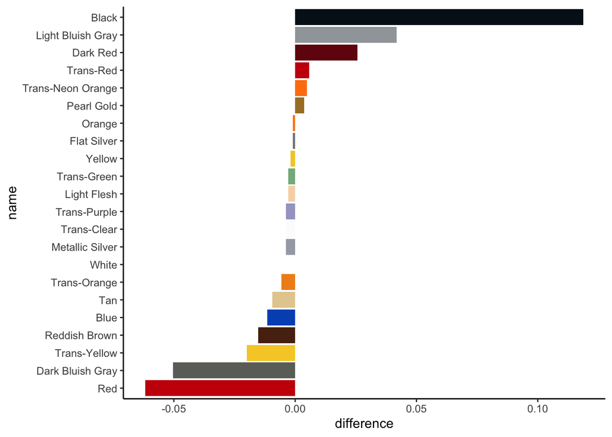

```r
color_palette <- setNames(colors_joined$rgb, colors_joined$name)

colors_joined %>%
  mutate(name = fct_reorder(name, difference)) %>%
  ggplot(aes(name, difference, fill = name)) +
  geom_col() +
  coord_flip() +
  scale_fill_manual(values = color_palette, guide = FALSE)
```

# 4. Case Study: Joins on Stack Overflow Data

Three of the Stack Overflow survey datasets are `questions`, `question_tags`, and `tags`:

- `questions`: an ID and the score, or how many times the question has been upvoted; the data only includes R-based questions
- `question_tags`: a tag ID for each question and the question’s id
- `tags`: a tag id and the tag’s name, which can be used to identify the subject of each question, such as `ggplot2` or `dplyr`

```r
questions = readRDS("data/questions.rds")
question_tags = readRDS("data/question_tags.rds")
tags = readRDS("data/tags.rds")
```

## 4.1 Stack Overflow questions

Coding exercises.

## 4.2 Joining questions and answers

Coding exercises.

## 4.3 The `bind_rows()` verb

- `bind_rows()` is the `dplyr` version of `rbind()`.